# Population per Crime against persons in 1830s France - Spatial Model

Piotr Wieczorek

2024-04-24

```r
rm(list=ls())
```

```r
options(scipen = 7)
```

### About the data set

The “Guerry” data set is a “Classic social science foundational study by Andre-Michel Guerry on crime, suicide, literacy and other “moral statistics” in 1830s France” (source: https://geodacenter.github.io/data-and-lab/Guerry/)

### Libraries

```r
library(spatialreg)
library(tidyverse)
library(sfdep)
library(spdep)
library(scales)
library(viridis)
library(olsrr)
library(png)
library(ggpubr)
```

```r
class(guerry)
```

```
## [1] "sf"         "tbl_df"     "tbl"        "data.frame"
```

### Loading the dataset

```r
data <- guerry
```

```r
data
```

```
## Simple feature collection with 85 features and 26 fields
## Geometry type: MULTIPOLYGON
## Dimension:     XY
## Bounding box:  xmin: 47680 ymin: 1703258 xmax: 1031401 ymax: 2677441
## CRS:           NA
## # A tibble: 85 × 27
##    code_dept count ave_id_geo  dept region department   crime_pers crime_prop
##    <fct>     <dbl>      <dbl> <int> <fct>  <fct>             <int>      <int>
##  1 01            1         49     1 E      Ain               28870      15890
##  2 02            1        812     2 N      Aisne             26226       5521
##  3 03            1       1418     3 C      Allier            26747       7925
##  4 04            1       1603     4 E      Basses-Alpes      12935       7289
##  5 05            1       1802     5 E      Hautes-Alpes      17488       8174
##  6 07            1       2249     7 S      Ardeche            9474      10263
##  7 08            1      35395     8 N      Ardennes          35203       8847
##  8 09            1       2526     9 S      Ariege             6173       9597
##  9 10            1      34410    10 E      Aube              19602       4086
## 10 11            1       2807    11 S      Aude              15647      10431
## # ℹ 75 more rows
## # ℹ 19 more variables: literacy <int>, donations <int>, infants <int>,
## #   suicides <int>, main_city <ord>, wealth <int>, commerce <int>,
## #   clergy <int>, crime_parents <int>, infanticide <int>,
## #   donation_clergy <int>, lottery <int>, desertion <int>, instruction <int>,
## #   prostitutes <int>, distance <dbl>, area <int>, pop1831 <dbl>,
## #   geometry <MULTIPOLYGON>
```

### Seeking neighbors

##### The neighbors are defined by contiguity. It means, that 2 units are neighbors only if they share a common side (in this case: a border)

```r
nb <- st_contiguity(guerry)
```

```r
nb
```

```
## Neighbour list object:
## Number of regions: 85
## Number of nonzero links: 420
## Percentage nonzero weights: 5.813149
## Average number of links: 4.941176
```

```r
attributes(nb)
```

```
## $class
## [1] "nb"   "list"
##
## $region.id
##  [1] "1"  "2"  "3"  "4"  "5"  "6"  "7"  "8"  "9"  "10" "11" "12" "13" "14" "15"
## [16] "16" "17" "18" "19" "20" "21" "22" "23" "24" "25" "26" "27" "28" "29" "30"
## [31] "31" "32" "33" "34" "35" "36" "37" "38" "39" "40" "41" "42" "43" "44" "45"
## [46] "46" "47" "48" "49" "50" "51" "52" "53" "54" "55" "56" "57" "58" "59" "60"
## [61] "61" "62" "63" "64" "65" "66" "67" "68" "69" "70" "71" "72" "73" "74" "75"
## [76] "76" "77" "78" "79" "80" "81" "82" "83" "84" "85"
##
## $call
## spdep::poly2nb(pl = geometry, queen = queen)
##
## $type
## [1] "queen"
##
## $sym
## [1] TRUE
```

```r
nb[1:3] #first observation has neighbors with observation 36,37,67,69 and so on..
```

```
## [[1]]
## [1] 36 37 67 69
##
## [[2]]
## [1]  7 49 57 58 73 76
##
## [[3]]
## [1] 17 21 40 56 61 69
```

### Compute spatial weights (row-standarized)

##### Row-standarization means that each element in the weight matrix gets divided by the sum within each row

```r
wt <- st_weights(nb) #spatial weights (row standardized)
```

```r
wt
```

```
## [[1]]
## [1] 0.25 0.25 0.25 0.25
##
## [[2]]
## [1] 0.1666667 0.1666667 0.1666667 0.1666667 0.1666667 0.1666667
##
## [[3]]
## [1] 0.1666667 0.1666667 0.1666667 0.1666667 0.1666667 0.1666667
##
## [[4]]
## [1] 0.25 0.25 0.25 0.25
##
## [[5]]
## [1] 0.3333333 0.3333333 0.3333333
##
## [[6]]
## [1] 0.1428571 0.1428571 0.1428571 0.1428571 0.1428571 0.1428571 0.1428571
##
## [[7]]
## [1] 0.3333333 0.3333333 0.3333333
##
## [[8]]
## [1] 0.3333333 0.3333333 0.3333333
##
## [[9]]
## [1] 0.2 0.2 0.2 0.2 0.2
##
## [[10]]
## [1] 0.2 0.2 0.2 0.2 0.2
##
## [[11]]
## [1] 0.1428571 0.1428571 0.1428571 0.1428571 0.1428571 0.1428571 0.1428571
##
## [[12]]
## [1] 0.3333333 0.3333333 0.3333333
##
## [[13]]
## [1] 0.3333333 0.3333333 0.3333333
##
## [[14]]
```

[output cut: 209 more lines]

```
## [[84]]
## [1] 0.1666667 0.1666667 0.1666667 0.1666667 0.1666667 0.1666667
##
## [[85]]
## [1] 0.2 0.2 0.2 0.2 0.2
##
## attr(,"mode")
## [1] "binary"
## attr(,"W")
## [1] TRUE
## attr(,"comp")
## attr(,"comp")$d
##  [1] 4 6 6 4 3 7 3 3 5 5 7 3 3 6 5 5 6 6 7 3 6 7 2 5 6 6 2 6 6 6 4 4 6 6 5 6 5 4
## [39] 6 7 5 4 7 6 6 5 8 4 6 6 5 4 5 4 2 6 3 6 6 2 6 3 3 2 4 2 4 5 7 6 2 3 8 6 5 5
## [77] 5 6 3 6 4 6 6 6 5
```

### Spatial lag

##### Spatial lag is computed as sum of multiplication of each neighbor row-standarized weight and its value for the variable of interest.

```r
x <- guerry$crime_pers
```

```r
st_lag(x,nb,wt)
```

```
##  [1] 23047.50 26919.67 26195.50 14401.25 15038.67 15749.00 22111.67 13672.33
##  [9] 22859.20 11475.20 12200.14 13278.67 24734.00 11752.83 17992.60 21974.40
## [17] 26711.00 19344.00 23696.71 25108.67 21643.17 18306.00 24280.00 14451.60
## [25] 21047.67 21421.33 25961.50 10869.83 13415.67 17172.17 20238.25 12504.25
## [33] 26723.00 21772.83 26462.20 19252.00 24683.20 20607.25 24412.00 19373.71
## [41] 16000.20 23993.25 20337.86 16818.67 17113.83 13013.00 22133.00 24093.75
## [49] 25661.67 22190.17 29030.00 16951.00 24509.00 24982.75 19491.50 24176.00
## [57] 27639.67 21274.33 24510.33 30166.00 23459.00 16184.00 18002.00 10910.00
## [65] 16251.25 15572.00 25884.25 23020.60 26495.00 24690.50 17339.00 25522.33
## [73] 18970.00 19701.83 21841.00 24520.40 14025.80 14565.17 13306.67 12579.00
## [81] 21529.50 23474.50 24373.17 19900.50 23373.60
```

##### For example, let’s take a look on the spatial lag for the first observation in the data set:

```r
ij <- nb[[1]]
wij <- wt[[1]]
xij <- x[ij]
```

```r
xij
```

```
## [1] 18785 26221 18793 28391
```

```r
sum(xij*wij)
```

```
## [1] 23047.5
```

#### Creating a data frame with neighbors, weights and spatial lag values

```r
crime_lags <- data %>%
  transmute(nb=st_contiguity(geometry),
            wt = st_weights(nb),
            crime_lag = st_lag(crime_pers,nb,wt))
```

### Map plots

#### Crime Rate in France

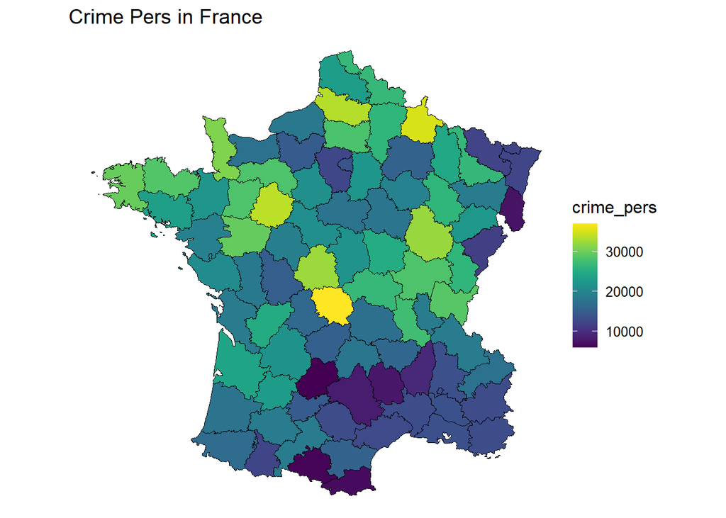

```r
guerry %>%
  ggplot(aes(fill=crime_pers)) +
  geom_sf(color="black") +
  viridis::scale_fill_viridis(option="c",direction = 1)+
  labs(title="Crime Pers in France")+
  theme_void(base_family = "Italic",
             base_size = 12)
```

#### Crime Rate in France - Spatial lags

##### It’s noticable that the data looks now like it’s grouped (or clustered). It’s because spatial lags are smoothed values since they are computed by taking into account all values from the neighbors for a particular local unit (and associated weights)

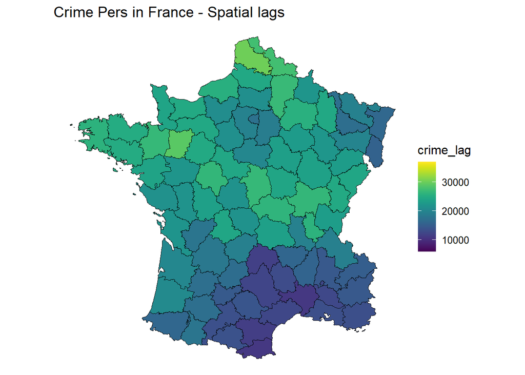

```r
crime_lags %>%
  ggplot(aes(fill=crime_lag)) +
  geom_sf(color="black",lwd=0.1) +
  viridis::scale_fill_viridis(option="c",direction = 1,limits = range(data$crime_pers))+
  labs(title="Crime Pers in France - Spatial lags")+
  theme_void(base_family = "Italic",
             base_size = 12)
```

### Creating a linear model WITHOUT special dependence

```r
mod1 <- lm(data = guerry, formula = crime_pers ~ region + literacy + donations  + wealth + commerce + clergy + infanticide  + lottery + desertion  + prostitutes)
```

```r
summary(mod1)
```

```
##
## Call:
## lm(formula = crime_pers ~ region + literacy + donations + wealth +
##     commerce + clergy + infanticide + lottery + desertion + prostitutes,
##     data = guerry)
##
## Residuals:
##      Min       1Q   Median       3Q      Max
## -10506.5  -3331.8   -458.2   2255.6  14731.5
##
## Coefficients:
##               Estimate Std. Error t value   Pr(>|t|)
## (Intercept) 14492.0534  4252.8696   3.408    0.00108 **
## regionE      1921.2306  2608.3839   0.737    0.46382
## regionN      2097.1906  2405.1669   0.872    0.38617
## regionS     -9775.6962  1977.0870  -4.944 0.00000493 ***
## regionW     -1543.8317  1987.9855  -0.777    0.43999
## literacy     -128.2979    63.8006  -2.011    0.04813 *
## donations      -0.2031     0.1360  -1.494    0.13967
## wealth        -70.2900    30.7457  -2.286    0.02523 *
## commerce       55.3344    35.2120   1.571    0.12052
## clergy         44.0587    29.5487   1.491    0.14038
## infanticide   114.7417    26.7200   4.294 0.00005462 ***
## lottery        89.0214    30.9071   2.880    0.00525 **
## desertion      79.4545    29.6812   2.677    0.00922 **
## prostitutes    -1.8553     1.2778  -1.452    0.15093
## ---
## Signif. codes:  0 '***' 0.001 '**' 0.01 '*' 0.05 '.' 0.1 ' ' 1
##
## Residual standard error: 5189 on 71 degrees of freedom
## Multiple R-squared:  0.5729, Adjusted R-squared:  0.4947
## F-statistic: 7.326 on 13 and 71 DF,  p-value: 0.000000007557
```

### Creating a linear model WITH spatial dependence

```r
nb2listw(nb)
```

```
## Characteristics of weights list object:
## Neighbour list object:
## Number of regions: 85
## Number of nonzero links: 420
## Percentage nonzero weights: 5.813149
## Average number of links: 4.941176
##
## Weights style: W
## Weights constants summary:
##    n   nn S0      S1       S2
## W 85 7225 85 37.2761 347.6683
```

#### Moran test for regression residuals

##### H0: No spatial dependence in regression residuals

##### Since p-value < 0.05, it should be concluded that there exists a spatial dependence within linear regression’s residuals, which means that a spatial linear model would be better than “default” linear regression model

```r
lm.morantest(mod1,listw = nb2listw(nb))
```

```
##
##  Global Moran I for regression residuals
##
## data:
## model: lm(formula = crime_pers ~ region + literacy + donations + wealth
## + commerce + clergy + infanticide + lottery + desertion + prostitutes,
## data = guerry)
## weights: nb2listw(nb)
##
## Moran I statistic standard deviate = 2.2072, p-value = 0.01365
## alternative hypothesis: greater
## sample estimates:
## Observed Moran I      Expectation         Variance
##       0.06124017      -0.07556923       0.00384209
```

```r
lm.LMtests(mod1,nb2listw(nb) , test = "RSlag")
```

```
##
##  Rao's score (a.k.a Lagrange multiplier) diagnostics for spatial
##  dependence
##
## data:
## model: lm(formula = crime_pers ~ region + literacy + donations + wealth
## + commerce + clergy + infanticide + lottery + desertion + prostitutes,
## data = guerry)
## test weights: listw
##
## RSlag = 2.9466, df = 1, p-value = 0.08606
```

#### Formula

##### The formula essentially means: Take the sum of multiplication of weights and Y values for each neighbor, scale with with Rho and add the X variables multiplied by their coefficients

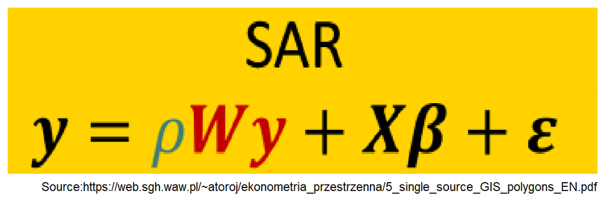

```r
ggplot() +
    background_image(readPNG("images/spatial_lag_formula.png")) +
  labs(caption = "Source:https://web.sgh.waw.pl/~atoroj/ekonometria_przestrzenna/5_single_source_GIS_polygons_EN.pdf")
```

```r
mod_spatial <- lagsarlm(formula = crime_pers ~ region + literacy + donations + wealth +
    commerce + clergy + infanticide + lottery + desertion + prostitutes,
    data = guerry,
    listw = nb2listw(nb))
```

#### SAR spatial lag model summary

```r
summary(mod_spatial,Nagelkerke = TRUE)
```

```
##
## Call:lagsarlm(formula = crime_pers ~ region + literacy + donations +
##     wealth + commerce + clergy + infanticide + lottery + desertion +
##     prostitutes, data = guerry, listw = nb2listw(nb))
##
## Residuals:
##      Min       1Q   Median       3Q      Max
## -9571.33 -3128.95  -423.67  2101.99 14644.70
##
## Type: lag
## Coefficients: (numerical Hessian approximate standard errors)
##                Estimate  Std. Error z value    Pr(>|z|)
## (Intercept)  9353.51602  4710.18827  1.9858    0.047055
## regionE      1806.32933  2324.56173  0.7771    0.437122
## regionN      1324.62589  2189.43787  0.6050    0.545174
## regionS     -8012.16252  1997.22272 -4.0117 0.000060295
## regionW     -1184.03491  1786.96944 -0.6626    0.507591
## literacy     -107.01173    58.16336 -1.8398    0.065791
## donations      -0.21177     0.12141 -1.7442    0.081123
## wealth        -63.62433    27.69009 -2.2977    0.021577
## commerce       46.10582    31.86279  1.4470    0.147894
## clergy         41.64859    26.42553  1.5761    0.115009
## infanticide   111.94125    23.86427  4.6907 0.000002722
## lottery        89.51933    27.54524  3.2499    0.001154
## desertion      65.18347    27.57976  2.3635    0.018106
## prostitutes    -1.61948     1.14915 -1.4093    0.158750
##
## Rho: 0.24614, LR test value: 3.2291, p-value: 0.072341
## Approximate (numerical Hessian) standard error: 0.13325
##     z-value: 1.8473, p-value: 0.064708
## Wald statistic: 3.4124, p-value: 0.064708
##
## Log likelihood: -838.4567 for lag model
## ML residual variance (sigma squared): 21360000, (sigma: 4621.7)
## Nagelkerke pseudo-R-squared: 0.58881
## Number of observations: 85
## Number of parameters estimated: 16
## AIC: 1708.9, (AIC for lm: 1710.1)
```

##### Nagelkerke pseudo-R-squared is slighly higher than R^2 in the OLS model

#### Model significance

##### Due to the feedback loop (global spatial lag was used), it is needed to compute the direct (the impact of a particular variable on the Y variable in a particular neighbor) and the indirect effect (the impact of a particular variable in the neighbors of a particular neighbor on the Y value of that neighbor)

```r
impacts(mod_spatial,listw = nb2listw(nb))
```

```
## Impact measures (lag, exact):
##                    Direct       Indirect          Total
## regionE      1831.6647784   564.44482910   2396.1096075
## regionN      1343.2050012   413.92132788   1757.1263290
## regionS     -8124.5405426 -2503.65402670 -10628.1945693
## regionW     -1200.6421007  -369.98922147  -1570.6313222
## literacy     -108.5126665   -33.43920471   -141.9518712
## donations      -0.2147432    -0.06617514     -0.2809183
## wealth        -64.5167172   -19.88143673    -84.3981539
## commerce       46.7525015    14.40722563     61.1597272
## clergy         42.2327479    13.01442080     55.2471687
## infanticide   113.5113261    34.97958897    148.4909151
## lottery        90.7749202    27.97315039    118.7480706
## desertion      66.0977332    20.36864178     86.4663750
## prostitutes    -1.6421955    -0.50605807     -2.1482535
```